# 1標本t検定・対応のあるt検定

あなたの名前

2026-10-07

# 課題（対応のあるt検定）

以下の表は、76系統からなるイネの遺伝解析分離集団において、出穂後のイネの茎葉部（穂以外の地上部, shoot weight, SW）の乾物重を測定したものである。

SW5=出穂後5日の茎葉重 (g/個体)

SW35=出穂後35日の茎葉重 (g/個体)

を示す。出穂後時間が経つと、穂に栄養を送って「枯れ上がる」系統と、「枯れ上がりにくい」系統が存在する。

課題１：Genotype=Aの系統群（Table 1, 24系統）において、SW35とSW5に差があるかどうかを検定しなさい。

課題２：Genotyoe=Bの系統群（Table 2, 52系統）において、SW35とSW5に差があるかどうかを検定しなさい。

課題３：Genotyoe=Bの系統群（Table 2, 52系統）において、SW35の平均がSW5よりも小さいかどうかを検定しなさい。

## 課題1

課題１：Genotype=Aの系統群（Table 1, 24系統）において、SW35とSW5に差があるかどうかを検定しなさい。

#### データを読み込む

課題ファイルをもとにデータファイルを作成して保存しておく。ファイル名は”table1.xlsx”とする。以下の操作を行う。

- データファイルを左クリックして「Import Dataset…」を選びImportする。

ここまででエラーが出る人はすぐに挙手！

RstudioのConsoleパネルに上記の操作に対応するコードが残る。以下の感じになる。

```
library(readxl)
table1 <- read_excel("table1.xlsx")
View(table1)
```

```r
library(readxl) # .xlsxファイルを読み込むライブラリ
# table1.xlsxをデータフレームtable1に格納
table1 <- read_excel("table1.xlsx")
```

#### グラフを描いてみる

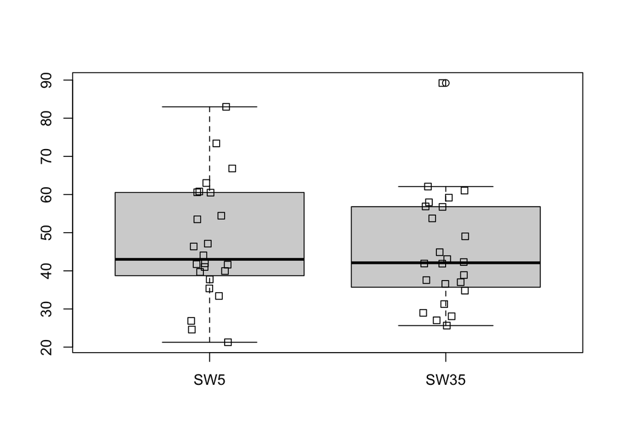

```r
#### グラフを描いてみる
# boxplotを描いてみる
boxplot(table1)
# boxplotの上にドットプロットを重ねて描く
stripchart(table1,
  vertical=TRUE, # 縦に
  method="jitter", # 近い点はランダムにずらす
  add=TRUE) # 前のグラフに追加（上書き）
```

対応する点を結んだドットプロットも描いてみる。

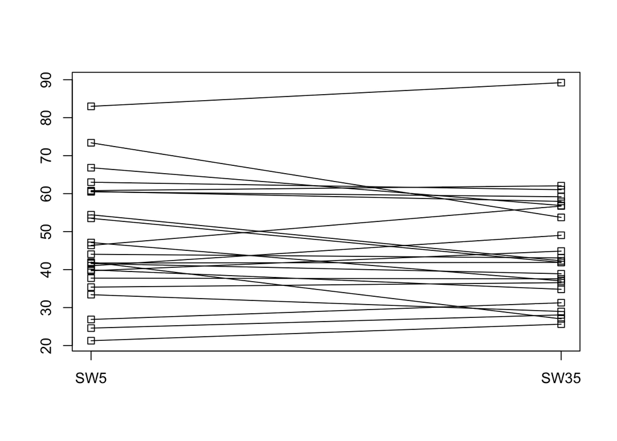

```r
# ドットプロットを描いて
stripchart(table1,vertical=TRUE)
# 線分を描く
for(i in 1:length(table1$SW5)){
lines(c(1,2),c(table1$SW5[i],table1$SW35[i]))
}
```

**【グラフから受ける印象】**

- 箱ひげ図およびドットプロットを見ると、出穂後5日（SW5）と出穂後35日（SW35）の間で中央値（SW5: 約43.0g, SW35: 約42.1g）やデータの分布・ばらつきに大きな違いは見られない。
- 同一系統の対応する点を結んだ折れ線グラフを見ると、SW5からSW35にかけて増加している系統も減少している系統もあり、線の傾きは正負まちまちで、全体として一貫した増減の傾向は認められない。
- したがって、Genotype=A の系統群においては、出穂後5日と出穂後35日の茎葉重に明らかな差はない（出穂後も枯れ上がりにくい）という印象を受ける。

#### 対応のあるt検定、両側検定

```r
# 対応のあるt検定
t.test(table1$SW5, table1$SW35, alternative='two.sided', conf.level=.95, paired=TRUE)
```

```
##
##  Paired t-test
##
## data:  table1$SW5 and table1$SW35
## t = 1.4209, df = 23, p-value = 0.1688
## alternative hypothesis: true mean difference is not equal to 0
## 95 percent confidence interval:
##  -1.007278  5.426261
## sample estimates:
## mean difference
##        2.209492
```

#### 課題1の結果の解釈

- **仮説の設定**
  - **帰無仮説 ($H_0$)**: 出穂後5日の茎葉重（SW5）と出穂後35日の茎葉重（SW35）の平均値に差はない（差の母平均 $\mu_d = 0$）
  - **対立仮説 ($H_1$)**: 出穂後5日の茎葉重（SW5）と出穂後35日の茎葉重（SW35）の平均値に差がある（差の母平均 $\mu_d \neq 0$）
  - **有意水準**: $\alpha = 0.05$ (5%)、両側検定
- **検定結果**
  - 検定統計量: $t = 1.4209$
  - 自由度: $df = 23$
  - $p$値: $p = 0.1688$
  - 95%信頼区間: $[-1.007, 5.426]$（0を含む）
  - 標本平均の差（SW5 - SW35）: $2.209$ g
- **結論と解釈**
  - 検定の結果、$p$値は $0.1688$ であり、有意水準 $0.05$ よりも大きい（$p > 0.05$）。
  - したがって、有意水準5%で帰無仮説は棄却されない。
  - **結論**: Genotype=A の系統群（24系統）において、出穂後5日の茎葉重（SW5）と出穂後35日の茎葉重（SW35）の間に統計学的に有意な差があるとはいえない。
  - **生物学的考察**: Genotype=A（ジャポニカアレル）をもつ系統群では、出穂後35日を経過しても茎葉重が顕著に減少しておらず、出穂後に「枯れ上がりにくい」特性をもつことが示唆される。

## 課題2

課題２：Genotyoe=Bの系統群（表2, 52系統）において、SW35とSW5に差があるかどうかを検定しなさい。

#### データを読み込む

表2からデータファイルtable2.xlsxを作成した。以下によりデータフレーム`table2`に読み込む。

```r
library(readxl) # .xlsxファイルを読み込むライブラリ
# データフレームtable2にExcelファイル"table2.xlsx"を読み込む
table2 <- read_excel("table2.xlsx")
table2 # うまく読み込まれたか確認する
```

```
## # A tibble: 52 × 2
##      SW5  SW35
##    <dbl> <dbl>
##  1  32.9  27.8
##  2  34.9  32.3
##  3  48.1  28.3
##  4  56.0  40.7
##  5  97.8  68.5
##  6  36.8  25.3
##  7  44.3  28.6
##  8  66.2  72.8
##  9  52.1  37.2
## 10  51.1  40.4
## # ℹ 42 more rows
```

#### グラフを描いてみる

箱ひげ図にドットプロットを重ねる。

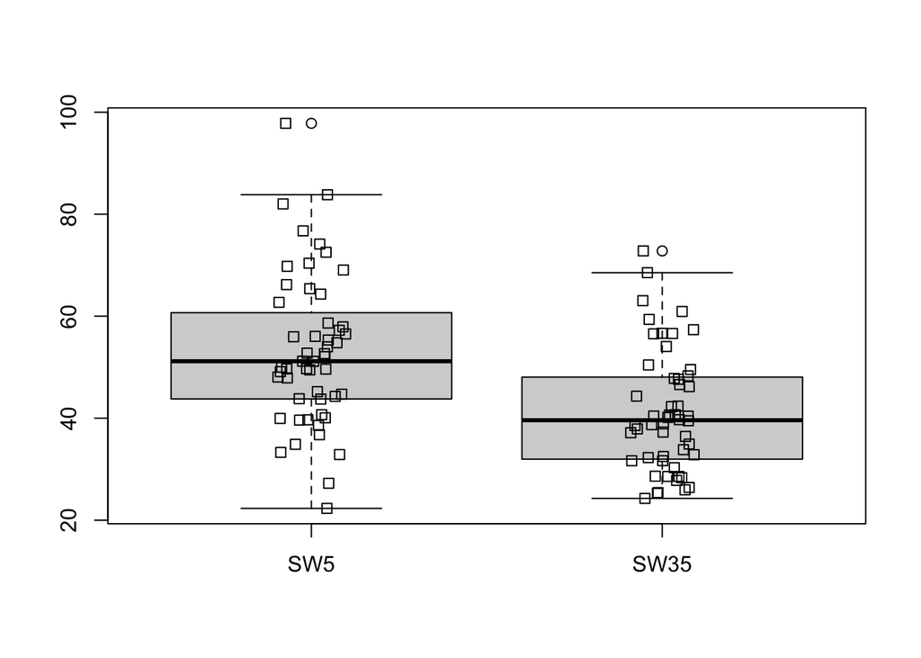

```r
#### グラフを描いている
# boxplotを描いてみる
boxplot(table2)
# boxplotの上にドットプロットを重ねて描く
stripchart(table2,
  vertical=TRUE, # 縦に
  method="jitter", # 近い点はランダムにずらす
  add=TRUE) # 前のグラフに追加（上書き）
```

ヒストグラムも描いてみる。

```r
split.screen(figs=c(2,1))
```

```
## [1] 1 2
```

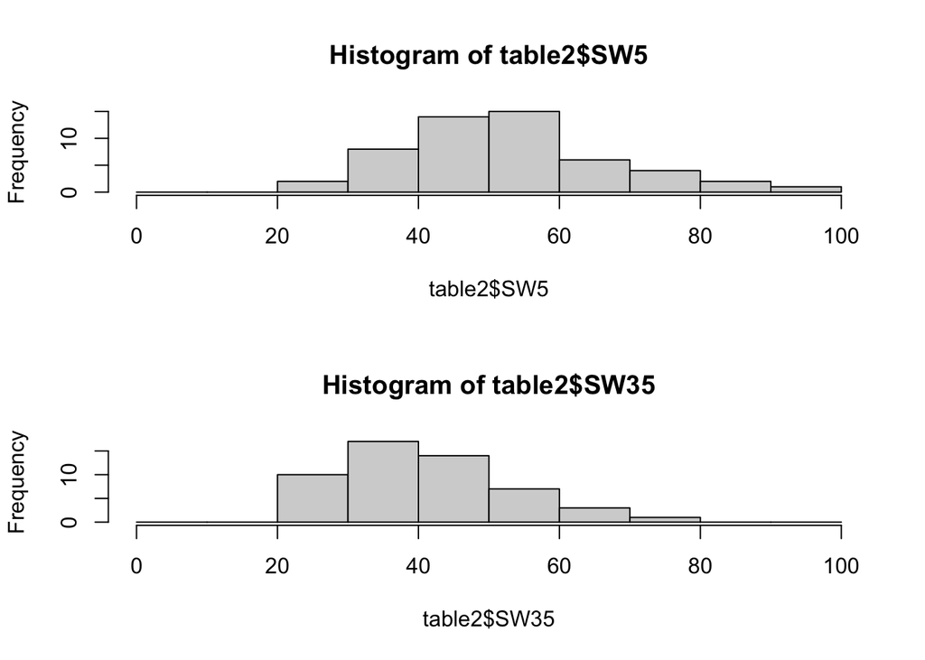

```r
screen(1);hist(table2$SW5,xlim=c(0,100),breaks=c(seq(0,100,by=10)))
screen(2);hist(table2$SW35,xlim=c(0,100),breaks=c(seq(0,100,by=10)))
```

```r
close.screen(all.screens=TRUE)
```

別のヒストグラムの描き方（半透明カラーを使用）

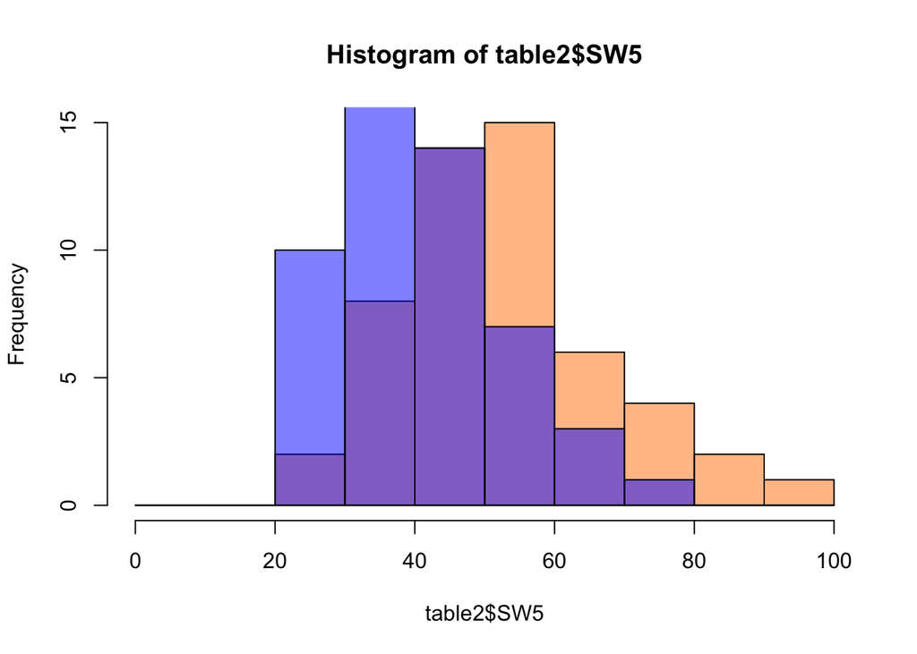

```r
hist(table2$SW5,xlim=c(0,100),breaks=c(seq(0,100,by=10)),col=rgb(1,0.5,0,alpha=0.5))
hist(table2$SW35,xlim=c(0,100),breaks=c(seq(0,100,by=10)),col=rgb(0,0,1,alpha=0.5),add=T)
```

対応する点を結んだドットプロットも描いてみる。

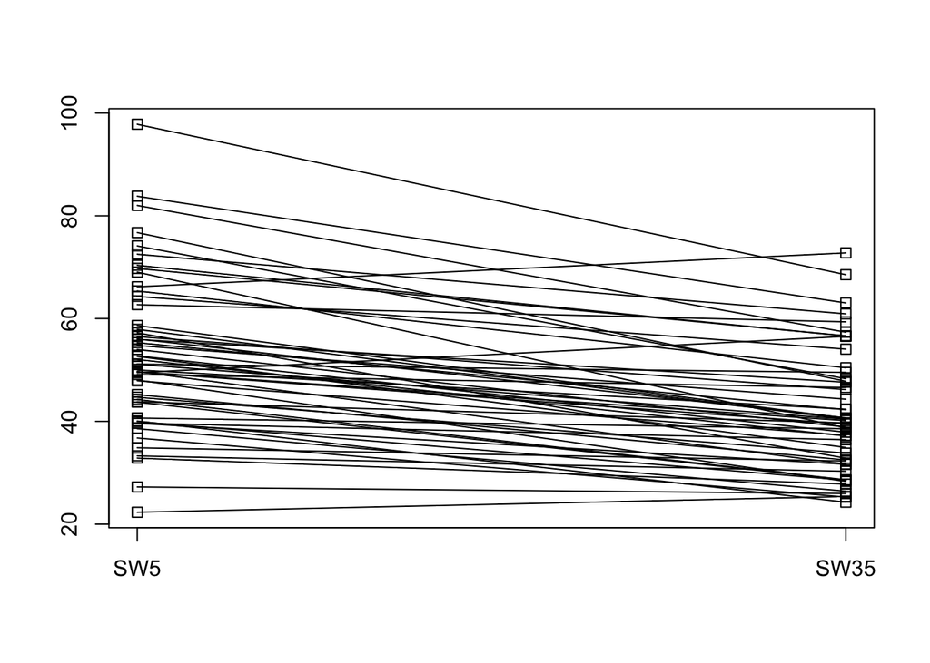

```r
# ドットプロットを用意して
stripchart(table2,vertical=TRUE)
# 線分を描く
for(i in 1:length(table2$SW5)){
lines(c(1,2),c(table2$SW5[i],table2$SW35[i]))
}
```

**【グラフから受ける印象】**

- 箱ひげ図・ドットプロットおよびヒストグラムを見ると、SW5（平均約53.1g, 中央値約51.2g）と比較して、SW35（平均約41.3g, 中央値約39.6g）の分布全体が低い値へ大きくシフトしていることがわかる。
- 同一系統の対応する点を結んだ折れ線グラフを見ると、52系統の大部分においてSW5からSW35にかけて右下がりの線となっており、出穂後35日において茎葉重が一貫して減少していることが視覚的に明瞭である。
- したがって、Genotype=B の系統群においては、SW35とSW5の間に明らかな差があり、出穂後に大きく減少している（枯れ上がっている）という印象を受ける。

#### 対応のあるt検定、両側検定

```r
# 対応のあるt検定（両側検定）
t.test(table2$SW5, table2$SW35, alternative='two.sided', conf.level=.95, paired=TRUE)
```

```
##
##  Paired t-test
##
## data:  table2$SW5 and table2$SW35
## t = 10.106, df = 51, p-value = 8.986e-14
## alternative hypothesis: true mean difference is not equal to 0
## 95 percent confidence interval:
##   9.48633 14.18949
## sample estimates:
## mean difference
##        11.83791
```

#### 課題2の結果の解釈

- **仮説の設定**
  - **帰無仮説 ($H_0$)**: 出穂後5日の茎葉重（SW5）と出穂後35日の茎葉重（SW35）の平均値に差はない（差の母平均 $\mu_d = 0$）
  - **対立仮説 ($H_1$)**: 出穂後5日の茎葉重（SW5）と出穂後35日の茎葉重（SW35）の平均値に差がある（差の母平均 $\mu_d \neq 0$）
  - **有意水準**: $\alpha = 0.05$ (5%)、両側検定
- **検定結果**
  - 検定統計量: $t = 10.106$
  - 自由度: $df = 51$
  - $p$値: $p = 8.986 \times 10^{-14}$（$p < 0.001$）
  - 95%信頼区間: $[9.486, 14.189]$（0を含まない）
  - 標本平均の差（SW5 - SW35）: $11.838$ g
- **結論と解釈**
  - 検定の結果、$p$値は $8.986 \times 10^{-14}$ であり、有意水準 $0.05$（さらには $0.001$）よりも極めて小さい（$p < 0.05$）。
  - したがって、有意水準5%で帰無仮説は棄却され、対立仮説が採択される。
  - **結論**: Genotype=B の系統群（52系統）において、出穂後5日の茎葉重（SW5）と出穂後35日の茎葉重（SW35）の間に統計学的に有意な差がある。
  - **生物学的考察**: Genotype=B（インディカアレル）をもつ系統群では、出穂後に茎葉重の顕著な変動が生じていることが確認された。

## 課題3

課題３：Genotyoe=Bの系統群（表2, 52系統）において、SW35の平均がSW5よりも小さいかどうかを検定しなさい。

#### データ

課題2のデータフレーム`table2`をそのまま使う。

#### 対応のあるt検定、片側検定

```r
# 対応のあるt検定（片側検定）
# 対立仮説 SW5 > SW35 (すなわち SW35 < SW5)
t.test(table2$SW5, table2$SW35, alternative='greater', conf.level=.95, paired=TRUE)
```

```
##
##  Paired t-test
##
## data:  table2$SW5 and table2$SW35
## t = 10.106, df = 51, p-value = 4.493e-14
## alternative hypothesis: true mean difference is greater than 0
## 95 percent confidence interval:
##  9.875567      Inf
## sample estimates:
## mean difference
##        11.83791
```

```r
# （参考）table2$SW35, table2$SW5 の順で与える場合は alternative='less'
# t.test(table2$SW35, table2$SW5, alternative='less', conf.level=.95, paired=TRUE)
```

#### 課題3の結果の解釈

- **仮説の設定**
  - **帰無仮説 ($H_0$)**: SW35の平均値はSW5の平均値以上である（または SW5とSW35の平均値に差はない、$\mu_{SW5} \le \mu_{SW35}$）
  - **対立仮説 ($H_1$)**: SW35の平均値はSW5の平均値よりも小さい（すなわち $\mu_{SW5} > \mu_{SW35}$、差 $\mu_{SW5} - \mu_{SW35} > 0$）
  - **有意水準**: $\alpha = 0.05$ (5%)、片側検定
- **検定結果**
  - 検定統計量: $t = 10.106$
  - 自由度: $df = 51$
  - $p$値: $p = 4.493 \times 10^{-14}$（$p < 0.001$）
  - 95%片側信頼区間: $[9.876, \infty)$
  - 標本平均の差（SW5 - SW35）: $11.838$ g
- **結論と解釈**
  - 検定の結果、$p$値は $4.493 \times 10^{-14}$ であり、有意水準 $0.05$ よりも極めて小さい（$p < 0.05$）。
  - したがって、有意水準5%で帰無仮説は棄却され、対立仮説が採択される。
  - **結論**: Genotype=B の系統群（52系統）において、出穂後35日の茎葉重（SW35）の平均は出穂後5日の茎葉重（SW5）よりも統計学的に有意に小さい（平均して約11.84 g 減少している）。

## 全体の考察（Genotype A と Genotype B の比較）

- **Genotype A（ジャポニカ型アレル）の系統群**:
  - SW5とSW35の間で茎葉重に統計学的有意差は認められなかった（$p = 0.1688$）。出穂後時間が経過しても茎葉重が維持されており、「枯れ上がりにくい」特性を示している。
- **Genotype B（インディカ型アレル）の系統群**:
  - SW35はSW5に比べて有意に小さいことが示された（$p = 4.493 \times 10^{-14}$）。出穂後35日において平均約11.84 gの茎葉重減少が認められ、「枯れ上がる」特性を示している。
- **生物学的意義**:
  - イネの登熟期において、出穂後の茎葉部に蓄えられた光合成産物や窒素などの栄養分が穂（登熟中の子実）へと活発に転流（再転流）されると、茎葉部は養分を失って乾物重が減少し「枯れ上がる（senescence）」現象が起きる。
  - 本解析結果から、この枯れ上がり特性の差を決める遺伝子座において、Genotype=A（ジャポニカアレル）は出穂後も茎葉重を保つ「ステイグリーン（stay-green）/ 枯れ上がりにくい」表現型と関連し、Genotype=B（インディカアレル）は穂への養分転流や老化が進みやすい「枯れ上がる」表現型と強く連鎖していることが示唆される。